# Class 9: Unsupervised Learning Analysis of Human Breast Cancer Cells

Arya Jahan April 30, 2019

# 1. Exploratory Data Analysis

## Preparing the Data

Read and Assign WisconsinCancer file

```r
fna.data <- "data/WisconsinCancer.csv"

wisc.df <- read.csv("WisconsinCancer.csv")
```

Select 3rd-32nd columns for use in new matrix

```r
wisc.data <- as.matrix(wisc.df[,3:32])
```

Assign Row Names

```r
row.names(wisc.data) <- wisc.df$id
```

Read Malignant or Benign diagnoses as 1 and 0 in new ‘diagnosis’ vector

```r
diagnosis <- as.numeric(wisc.df$diagnosis == "M")

diagnosis
```

```
##   [1] 1 1 1 1 1 1 1 1 1 1 1 1 1 1 1 1 1 1 1 0 0 0 1 1 1 1 1 1 1 1 1 1 1 1 1
##  [36] 1 1 0 1 1 1 1 1 1 1 1 0 1 0 0 0 0 0 1 1 0 1 1 0 0 0 0 1 0 1 1 0 0 0 0
##  [71] 1 0 1 1 0 1 0 1 1 0 0 0 1 1 0 1 1 1 0 0 0 1 0 0 1 1 0 0 0 1 1 0 0 0 0
## [106] 1 0 0 1 0 0 0 0 0 0 0 0 1 1 1 0 1 1 0 0 0 1 1 0 1 0 1 1 0 1 1 0 0 1 0
## [141] 0 1 0 0 0 0 1 0 0 0 0 0 0 0 0 0 1 0 0 0 0 1 1 0 1 0 0 1 1 0 0 1 1 0 0
## [176] 0 0 1 0 0 1 1 1 0 1 0 1 0 0 0 1 0 0 1 1 0 1 1 1 1 0 1 1 1 0 1 0 1 0 0
## [211] 1 0 1 1 1 1 0 0 1 1 0 0 0 1 0 0 0 0 0 1 1 0 0 1 0 0 1 1 0 1 0 0 0 0 1
## [246] 0 0 0 0 0 1 0 1 1 1 1 1 1 1 1 1 1 1 1 1 1 0 0 0 0 0 0 1 0 1 0 0 1 0 0
## [281] 1 0 1 1 0 0 0 0 0 0 0 0 0 0 0 0 0 1 0 0 1 0 1 0 0 0 0 0 0 0 0 0 0 0 0
## [316] 0 0 1 0 0 0 1 0 1 0 0 0 0 1 1 1 0 0 0 0 1 0 1 0 1 0 0 0 1 0 0 0 0 0 0
## [351] 0 1 1 1 0 0 0 0 0 0 0 0 0 0 0 1 1 0 1 1 1 0 1 1 0 0 0 0 0 1 0 0 0 0 0
## [386] 1 0 0 0 1 0 0 1 1 0 0 0 0 0 0 1 0 0 0 0 0 0 0 1 0 0 0 0 0 1 0 0 1 0 0
## [421] 0 0 0 0 0 0 0 0 0 0 1 0 1 1 0 1 0 0 0 0 0 1 0 0 1 0 1 0 0 1 0 1 0 0 0
## [456] 0 0 0 0 0 1 1 0 0 0 0 0 0 1 0 0 0 0 0 0 0 0 0 0 1 0 0 0 0 0 0 0 1 0 1
## [491] 0 0 1 0 0 0 0 0 1 1 0 1 0 1 0 0 0 0 0 1 0 0 1 0 1 0 1 1 0 0 0 1 0 0 0
## [526] 0 0 0 0 0 0 0 0 1 0 1 1 0 0 0 0 0 0 0 0 0 0 0 0 0 0 0 0 0 0 0 0 0 0 0
## [561] 0 0 1 1 1 1 1 1 0
```

Q1: How many observations are in the dataset?

```r
nrow(wisc.data)
```

```
## [1] 569
```

Q2: How many variables/features in the data are suffixed with _mean?

```r
length(grep("_mean", colnames(wisc.data)))
```

```
## [1] 10
```

Q3: How many observations have a malignant diagnosis?

```r
table(wisc.df$diagnosis)
```

```
##
##   B   M
## 357 212
```

# 2. Principal Component Analysis

## Performing PCA

Check column means and standard deviations, then round

```r
round(colMeans(wisc.data), 1)
```

```
##             radius_mean            texture_mean          perimeter_mean
##                    14.1                    19.3                    92.0
##               area_mean         smoothness_mean        compactness_mean
##                   654.9                     0.1                     0.1
##          concavity_mean     concave.points_mean           symmetry_mean
##                     0.1                     0.0                     0.2
##  fractal_dimension_mean               radius_se              texture_se
##                     0.1                     0.4                     1.2
##            perimeter_se                 area_se           smoothness_se
##                     2.9                    40.3                     0.0
##          compactness_se            concavity_se       concave.points_se
##                     0.0                     0.0                     0.0
##             symmetry_se    fractal_dimension_se            radius_worst
##                     0.0                     0.0                    16.3
##           texture_worst         perimeter_worst              area_worst
##                    25.7                   107.3                   880.6
##        smoothness_worst       compactness_worst         concavity_worst
##                     0.1                     0.3                     0.3
##    concave.points_worst          symmetry_worst fractal_dimension_worst
##                     0.1                     0.3                     0.1
```

```r
round(apply(wisc.data,2,sd), 1)
```

```
##             radius_mean            texture_mean          perimeter_mean
##                     3.5                     4.3                    24.3
##               area_mean         smoothness_mean        compactness_mean
##                   351.9                     0.0                     0.1
##          concavity_mean     concave.points_mean           symmetry_mean
##                     0.1                     0.0                     0.0
##  fractal_dimension_mean               radius_se              texture_se
##                     0.0                     0.3                     0.6
##            perimeter_se                 area_se           smoothness_se
##                     2.0                    45.5                     0.0
##          compactness_se            concavity_se       concave.points_se
##                     0.0                     0.0                     0.0
##             symmetry_se    fractal_dimension_se            radius_worst
##                     0.0                     0.0                     4.8
##           texture_worst         perimeter_worst              area_worst
##                     6.1                    33.6                   569.4
##        smoothness_worst       compactness_worst         concavity_worst
##                     0.0                     0.2                     0.2
##    concave.points_worst          symmetry_worst fractal_dimension_worst
##                     0.1                     0.1                     0.0
```

Execute PCA with the **prcomp()** function

```r
wisc.pr <- prcomp((wisc.data), scale = TRUE)

summary(wisc.pr)
```

```
## Importance of components:
##                           PC1    PC2     PC3     PC4     PC5     PC6
## Standard deviation     3.6444 2.3857 1.67867 1.40735 1.28403 1.09880
## Proportion of Variance 0.4427 0.1897 0.09393 0.06602 0.05496 0.04025
## Cumulative Proportion  0.4427 0.6324 0.72636 0.79239 0.84734 0.88759
##                            PC7     PC8    PC9    PC10   PC11    PC12
## Standard deviation     0.82172 0.69037 0.6457 0.59219 0.5421 0.51104
## Proportion of Variance 0.02251 0.01589 0.0139 0.01169 0.0098 0.00871
## Cumulative Proportion  0.91010 0.92598 0.9399 0.95157 0.9614 0.97007
##                           PC13    PC14    PC15    PC16    PC17    PC18
## Standard deviation     0.49128 0.39624 0.30681 0.28260 0.24372 0.22939
## Proportion of Variance 0.00805 0.00523 0.00314 0.00266 0.00198 0.00175
## Cumulative Proportion  0.97812 0.98335 0.98649 0.98915 0.99113 0.99288
##                           PC19    PC20   PC21    PC22    PC23   PC24
## Standard deviation     0.22244 0.17652 0.1731 0.16565 0.15602 0.1344
## Proportion of Variance 0.00165 0.00104 0.0010 0.00091 0.00081 0.0006
## Cumulative Proportion  0.99453 0.99557 0.9966 0.99749 0.99830 0.9989
##                           PC25    PC26    PC27    PC28    PC29    PC30
## Standard deviation     0.12442 0.09043 0.08307 0.03987 0.02736 0.01153
## Proportion of Variance 0.00052 0.00027 0.00023 0.00005 0.00002 0.00000
## Cumulative Proportion  0.99942 0.99969 0.99992 0.99997 1.00000 1.00000
```

Compare PC1 and PC2

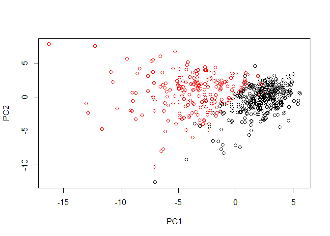

```r
plot(wisc.pr$x[,1], wisc.pr$x[,2], col=diagnosis+1, xlab="PC1", ylab="PC2")
```

Q4. From your results, what proportion of the original variance is captured by the first principal components (PC1)? 44%

Q5. How many principal components (PCs) are required to describe at least 70% of the original variance in the data? 3 Principal Components

Q6. How many principal components (PCs) are required to describe at least 90% of the original variance in the data? 7 Principal Components

## Interpreting PCA Results

Create a biplot

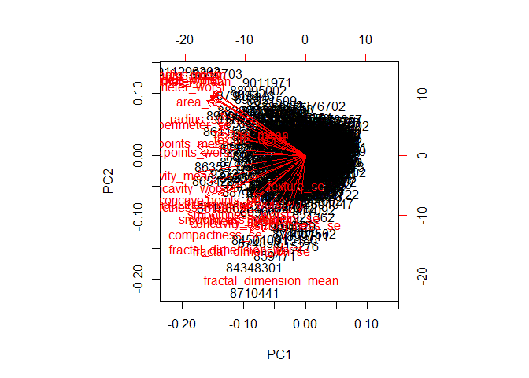

```r
biplot(wisc.pr)
```

Q7. What stands out to you about this plot? Is it easy or difficult to understand? Why? It is difficult to understand.

Compare PC1 and PC3

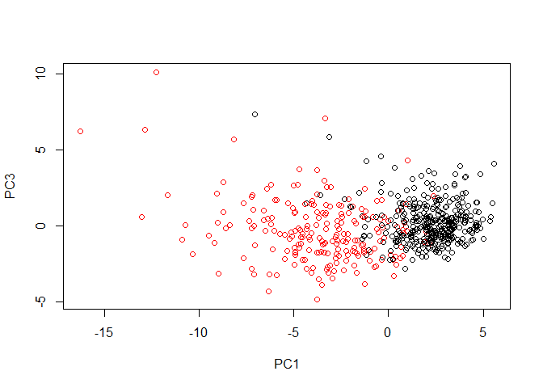

```r
plot(wisc.pr$x[,1], wisc.pr$x[,3], col=diagnosis+1, xlab="PC1", ylab="PC3")
```

Q8. Generate a similar plot for principal components 1 and 3. What do you notice about these plots? The plots are similar along the x-axis (PC1), and different along the y-axis (PC2 v PC3). The first plot explains more variance

## Variance Explained

Calculate the variance of each PC

```r
pr.var <- wisc.pr$sdev^2
head(pr.var)
```

```
## [1] 13.281608  5.691355  2.817949  1.980640  1.648731  1.207357
```

Calculate the total variance explained

```r
pve <- pr.var/sum(pr.var)
head(pve)
```

```
## [1] 0.44272026 0.18971182 0.09393163 0.06602135 0.05495768 0.04024522
```

Make a Scree Plot

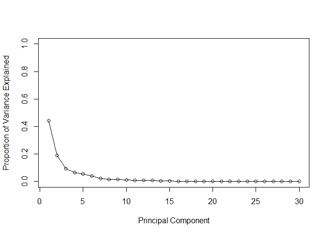

```r
plot(pve, xlab = "Principal Component",
     ylab = "Proportion of Variance Explained",
     ylim = c(0, 1), type = "o")
```

Alternative scree plot of the same data, note data driven y-axis

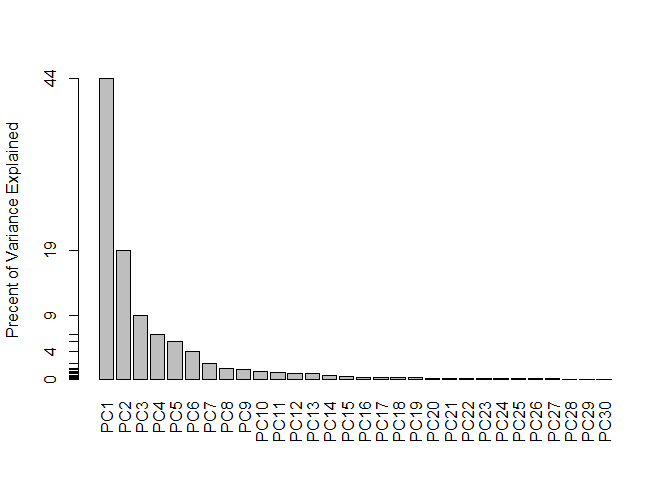

```r
barplot(pve, ylab = "Precent of Variance Explained",
     names.arg=paste0("PC",1:length(pve)), las=2, axes = FALSE)
axis(2, at=pve, labels=round(pve,2)*100 )
```

Plot cumulative proportion of variance explained

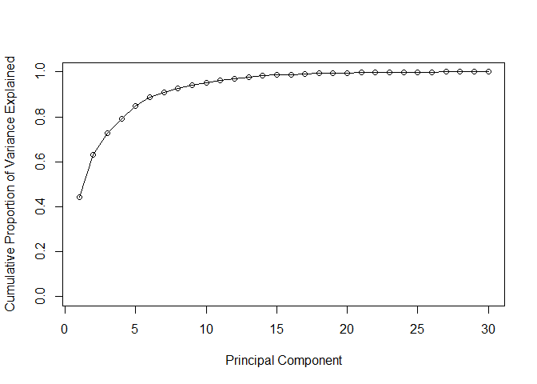

```r
plot(cumsum(pve), xlab = "Principal Component",
     ylab = "Cumulative Proportion of Variance Explained",
     ylim = c(0, 1), type = "o")
```

Setup side-by-side plots

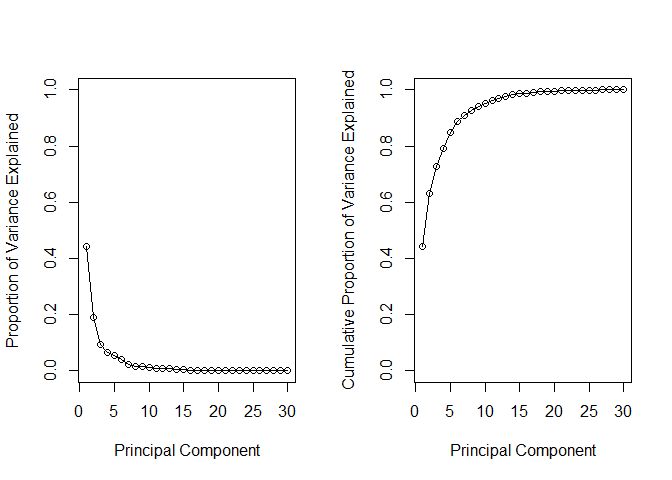

```r
par(mfcol=c(1,2))

plot(pve, xlab = "Principal Component",
     ylab = "Proportion of Variance Explained",
     ylim = c(0, 1), type = "o")

plot(cumsum(pve), xlab = "Principal Component",
     ylab = "Cumulative Proportion of Variance Explained",
     ylim = c(0, 1), type = "o")
```

# 3. Hierarchical Clustering

## Hierarchical clustering of case data

Scale the data

```r
data.scaled <- scale(wisc.data)
```

Calculate distances

```r
data.dist <- dist(data.scaled)
```

Create hierarchical clustering model

```r
wisc.hclust <- hclust(data.dist, method = "complete")
```

## Results of Hierarchical Clustering

Q11. Using the plot() and abline() functions, what is the height at which the clustering model has 4 clusters?

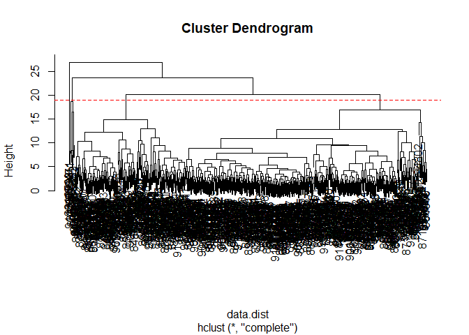

```r
plot(wisc.hclust)
abline(h=19, col = "red", lty=2)
```

# 5. Combining Methods

## Clustering on PCA Results

Describe at least 90% of the data

```r
wisc.pr.hclust <- (hclust(dist(wisc.pr$x[,1:7]), method="ward.D2"))
```

Plot hclust

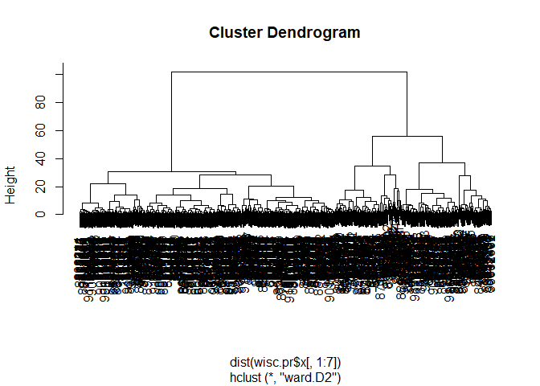

```r
plot(wisc.pr.hclust)
```

Cut into two groups

```r
grps <- cutree(wisc.pr.hclust, k=2)
table(grps)
```

```
## grps
##   1   2
## 216 353
```

Compare Cluster membership to actual diagnoses

```r
table(grps, diagnosis)
```

```
##     diagnosis
## grps   0   1
##    1  28 188
##    2 329  24
```

Plot by Cluster membership

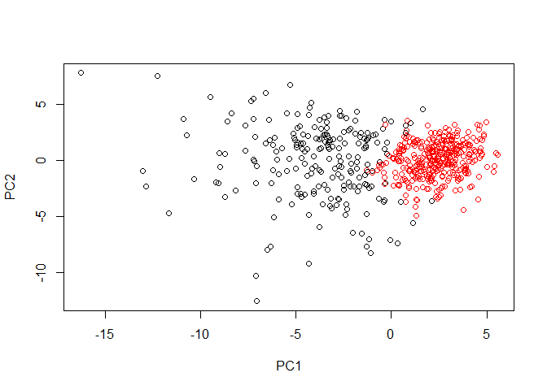

```r
plot(wisc.pr$x[,1:2], col=grps)
```

Plot by diagnosis

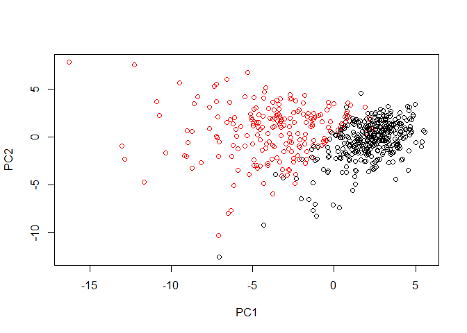

```r
plot(wisc.pr$x[,1:2], col=diagnosis+1)
```

# 7. Prediction

Use our PCA model to predict using new data

Read new data

```r
url <- "https://tinyurl.com/new-samples-CSV"
new <- read.csv(url)
```

```r
npc <- predict(wisc.pr, newdata=new)
npc
```

```
##            PC1       PC2        PC3        PC4       PC5        PC6
## [1,]  2.576616 -3.135913  1.3990492 -0.7631950  2.781648 -0.8150185
## [2,] -4.754928 -3.009033 -0.1660946 -0.6052952 -1.140698 -1.2189945
##             PC7        PC8       PC9       PC10      PC11      PC12
## [1,] -0.3959098 -0.2307350 0.1029569 -0.9272861 0.3411457  0.375921
## [2,]  0.8193031 -0.3307423 0.5281896 -0.4855301 0.7173233 -1.185917
##           PC13     PC14      PC15       PC16        PC17        PC18
## [1,] 0.1610764 1.187882 0.3216974 -0.1743616 -0.07875393 -0.11207028
## [2,] 0.5893856 0.303029 0.1299153  0.1448061 -0.40509706  0.06565549
##             PC19       PC20       PC21       PC22       PC23       PC24
## [1,] -0.08802955 -0.2495216  0.1228233 0.09358453 0.08347651  0.1223396
## [2,]  0.25591230 -0.4289500 -0.1224776 0.01732146 0.06316631 -0.2338618
##             PC25         PC26         PC27        PC28         PC29
## [1,]  0.02124121  0.078884581  0.220199544 -0.02946023 -0.015620933
## [2,] -0.20755948 -0.009833238 -0.001134152  0.09638361  0.002795349
##              PC30
## [1,]  0.005269029
## [2,] -0.019015820
```

Plot new patients against our PCA plot

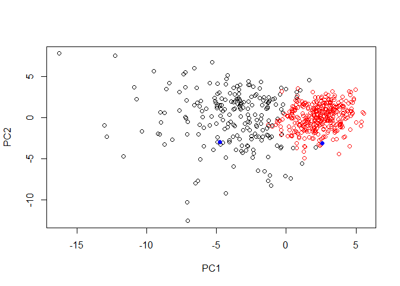

```r
plot(wisc.pr$x[,1:2], col=grps)
points(npc[,1], npc[,2], col="blue", pch=16)
```

## The patient in the black cluster needs to be paid attention!